# Sociología del Género

SOL3061 | Clase 7. Sexualidad

Tania Hutt

## Sexualidad como construcción social

(Benavente & Vergara 2006)

**Definición**

La sexualidad es un **constructo social**: una capacidad física para la excitación sexual y el placer, significados personales y socialmente compartidos que forman las **identidades sexuales y de género**, y una interpretación cultural de funciones “naturales” ordenadas en **relaciones sociales jerárquicas**.

- No es un impulso biológico que se expresa solo: se **aprende** y se **vigila**.
- Tres dimensiones: **capacidad física**, **significados compartidos** e **interpretación cultural** jerárquica.

## La sexualidad como sistema de normas

(Gagnon & Simon 1973; Risman 2004)

#### Individual

Guiones **intrapsíquicos**: lo que deseo y me permito desear.

→

#### Interaccional

Guiones **interpersonales**: quién propone, quién responde, qué “cuenta” como sexo.

→

#### Cultural e institucional

**Escenarios culturales**: escuela, medios, religión, leyes y también las **encuestas**.

- La sexualidad no es un impulso natural que se expresa solo: se **aprende** y se **vigila**.

## Cuerpo para sí, cuerpo para otro

(Benavente & Vergara 2006, cap. I, pp. 40–45)

**Hombres: cuerpo para sí**

- Ejercer la sexualidad **reafirma la hombría**
- Sexualidad sin control como parte de la identidad de género
- Se espera que adquieran **experiencia**
- Excitación física como algo **natural**
- Placer como parte de sus vidas

**Mujeres: cuerpo para otro**

- Discurso centrado en la **menstruación** y el cuidado del cuerpo
- **Secreto** y falta de información
- Menstruación como inicio del **riesgo** y de la necesidad de cuidarse
- **Temor y vergüenza** del cuerpo sexuado
- Lo femenino como **objeto** de placer

## Heteronormatividad y el imperativo del coito

(McPhillips, Braun & Gavey 2001)

- **Hetero- y mononormatividad:** se supone la heterosexualidad y la monogamia.
- **Imperativo del coito:** el “sexo de verdad” es la penetración pene-vagina; todo lo demás “no cuenta”.
  - Asume heterosexualidad
  - La dificultad o falta de deseo de penetración se lee como **“disfunción”**
  - Como los hombres suelen tener orgasmo con la penetración y las mujeres muchas veces no, el guion prioriza el **orgasmo masculino**
- Los guiones definen roles: él **toma la iniciativa** (asertivo), ella **responde** (receptiva, paciente).

## Cuando las categorías no calzan

(Pfeffer 2014)

- Mujeres en pareja con **hombres trans** son leídas como **heterosexuales** por quienes las rodean.
- Pfeffer reemplaza “*passing*” por **reconocimiento** (Connell): pertenecer a un grupo depende de cómo nos **leen** los demás.
- El (des)reconocimiento revela más sobre el **privilegio normativo** que sobre las personas.

Si la orientación sexual se infiere del género de la pareja, ¿qué pasa cuando ese género no se “ve” como se espera?

## ¿Qué mide una encuesta? ENSSEX 2022–2023

- Bienestar con la vida sexual (1–7): hombres **5,3**, mujeres **4,8**.
- **62,4%** cree que, sin orgasmo, una relación sexual no es “verdaderamente satisfactoria”.
- La **pregunta** misma incorpora una norma.

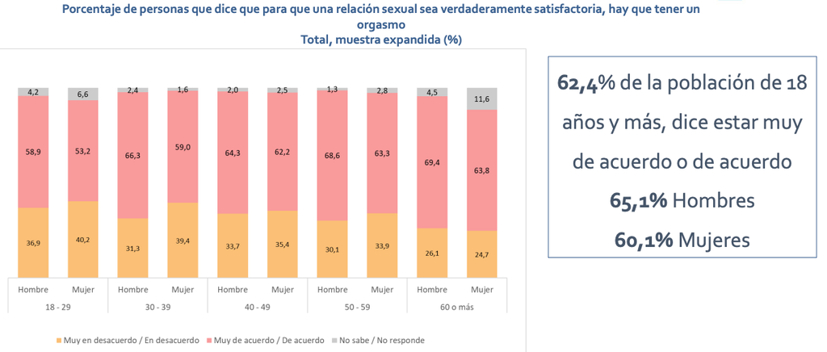

## ¿Es biológica la “brecha del orgasmo”?

(Frederick, St. John, Garcia & Lloyd 2018)

| Orgasmo “habitualmente o siempre” en el sexo con pareja | % |
| --- | --- |
| Hombres heterosexuales | **95** |
| Hombres gays | 89 |
| Hombres bisexuales | 88 |
| Mujeres lesbianas | **86** |
| Mujeres bisexuales | 66 |
| Mujeres heterosexuales | **65** |

- Si la brecha fuera solo biológica, las lesbianas no estarían cerca de los hombres.

## Justicia íntima: la satisfacción no basta

(McClelland 2010, 2014)

- Lo que sentimos que **merecemos** depende de nuestra posición social.
- Por eso la **satisfacción declarada** no mide igualdad.
- Al responder, las mujeres asocian el extremo bajo de la escala con **dolor**; los hombres, con **no tener sexo**.
- Las mujeres también califican alto cuando **su pareja** está satisfecha.

Si hombres y mujeres dijeran estar igual de satisfechos, ¿habría igualdad sexual?

## Placer, performance y fingimiento

- **Armstrong, England & Fogarty (2012)**: mujeres reportan más orgasmo en relaciones que en encuentros casuales — en parte porque en las relaciones hay más prácticas que favorecen el orgasmo femenino, y por un **doble estándar** que cuestiona el derecho de ellas al placer en encuentros casuales.
- **Jackson & Scott (2007)**: el placer y el orgasmo son una **performance interactiva** — “leer” a la pareja y producir una actuación calibrada. Fingir = **trabajo emocional** de mantener la relación heterosexual.
- **Chadwick & van Anders (2017)**: experimento con viñetas (N=810 hombres) — cuando la mujer tiene orgasmo, funciona como **logro de masculinidad**. Esto podría dar luces de una razón por qué algunas mujeres fingen.